# Word Dokumente mit R und Rstudio erstellen

Jan-Philipp Kolb

08 Mai 2017

# Ein Markdown Dokument mit Rstudio erzeugen

[figure not shown]

# Mein erstes mit R erzeugtes Word Dokument

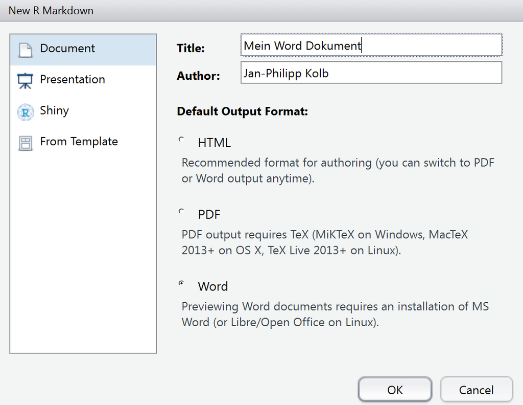

# Erstes Beispiel

[figure not shown]

# Das Arbeiten mit Markdown

# Rmarkdown - erste Schritte

Markdown ist eine sehr einfache Syntax, die es Benutzern erlaubt, aus einfachen Textdateien gut gelayoutete Dokumente zu erstellen.

```
**fettes Beispiel**
*kursives Beispiel*
~~durchgestrichen~~
- Aufzählungspunkt
```

**fettes Beispiel**

*kursives Beispiel*

durchgestrichen

- Aufzählungspunkt

# Weitere Markdown Befehle

```
### Überschrift Ebene 3
#### Überschrift Ebene 4
[Meine Github Seite](https://github.com/Japhilko)
```

### Überschrift Ebene 3

#### Überschrift Ebene 4

[Meine Github Seite](https://github.com/Japhilko)

# Weitere Markdown Befehle

- So kann man Bilder einbinden:
- Man kann entweder einen Link angeben:

```
![BSP](http://e-scientifics.de/content/example_kinderbild.jpg)
```

- oder einen (Unterordner) in dem das Bild liegt:

```
![BSP 2](figure/example.png)
```

- in den eckigen Klammern steht die Bildunterschrift
- alle gängigen Formate (.png, .jpeg,.gif) können so eingebunden werden
- Man kann auch noch weitere Optionen spezifizieren (Größe, Breite etc.) - dazu später mehr

# Chunks - Erste Schritte

- Es lassen sich so genannte Chunks einfügen
- In diesen Chunks wird ganz normaler R-code geschrieben

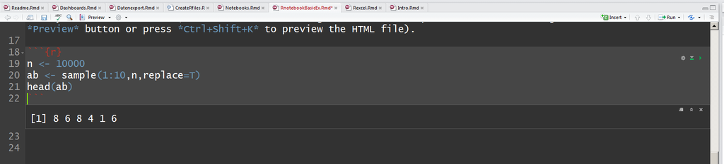

# Button um Chunks einzufügen

- Die default Version eines Chunks ist R
- Man hat aber auch die Möglichkeit andere Programmiersprachen einzubinden

[figure not shown]

# Inline Code

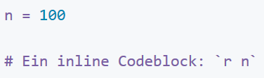

```r
n=100
```

Ein inline Codeblock: 100

# Chunk Optionen

- [Man kann den Chunks Optionen mitgeben:](https://yihui.name/knitr/options/)

| Argument | Beschreibung |
| --- | --- |
| eval | Soll Rcode evaluiert werden? |
| warning | Sollen Warnings angezeigt werden? |
| cache | Soll der Output gespeichert werden? |

- Bei eval kann ein logischer Wert angegeben werden oder eine/mehrere Nummer(n)

# Optionen

[figure not shown]

# Optionen für Word Output

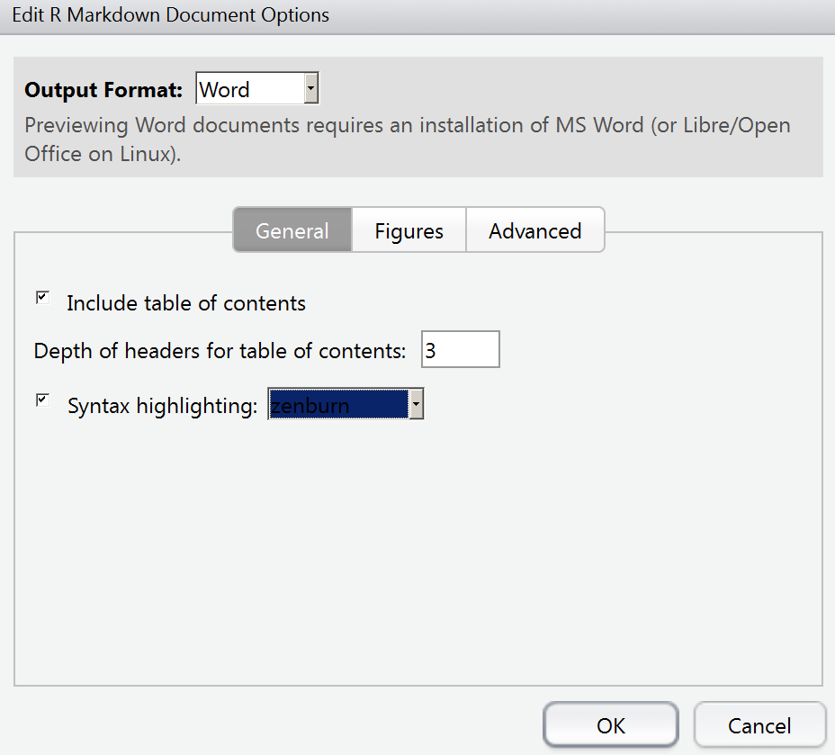

# Code Hervorhebung

- pygments Hervorhebung

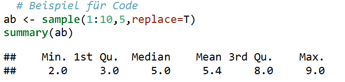

- tango

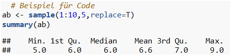

# Das Paket `knitr`

```r
install.packages("knitr")
```

```r
library("knitr")
```

- Das Paket knitr enthält zahlreiche wichtige Funktionen
- Beispiel: Befehl `kable` um Tabellen zu erzeugen

# Eine Tabelle mit `kable` erzeugen

```r
a <- runif(10)
b <- rnorm(10)
ab <- cbind(a,b)
kable(ab)
```

| a | b |
| --- | --- |
| 0.7655539 | -1.2469692 |
| 0.9045659 | -0.6117800 |
| 0.6150922 | -1.1735503 |
| 0.9342054 | 0.1656214 |
| 0.9256555 | 2.0401598 |
| 0.3395892 | -0.3731309 |
| 0.2730326 | -1.1094901 |
| 0.3970786 | 0.9770288 |
| 0.8231929 | -1.5882674 |
| 0.7736743 | 0.0356070 |

# [Vorlagen verwenden](http://rmarkdown.rstudio.com/articles_docx.html)

- Formatvorlagen können verändert werden
1. Ein Word Dokument mit Rmarkdown erstellen
2. Das Dokument in Word öffnen und Format verändern
3. Vorlage als Referenz angeben

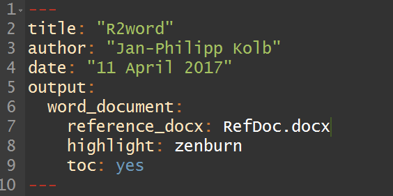

# Resourcen

- Interview - [Ein Word Dokument mit wenig Aufwand schreiben](https://www.r-statistics.com/2013/03/write-ms-word-document-using-r-with-as-little-overhead-as-possible/)
- [pander: Ein R Pandoc Wrapper](http://rapporter.github.io/pander/)
- [Ein Schummelzettel](https://www.rstudio.com/wp-content/uploads/2015/06/rmarkdown-german.pdf)
- [Einführung in Markdown](https://github.com/ctreffe/r-space/wiki/R-Markdown-Intro)
- [Warum TeX besser als Word ist](http://factorgrad.blogspot.de/2010/07/why-latex-is-superior-to-ms-word.html)